# RPKM

## How to calculate RPKM (Reads per Kilobase per Milion)

1. Count up the total reads in a sample and divide that number by 1,000,000 – this is our “per million” scaling factor.
2. Divide the read counts by the “per million” scaling factor. This normalizes for sequencing depth, giving you reads per million (RPM)
3. Divide the RPM values by the length of the gene, in kilobases. This gives you RPKM.

RPKM = numReads / ( geneLength/1000 * totalNumReads/1,000,000 )

numReads - number of reads mapped to a gene sequence (All Mapped Reads)  
geneLength - length of the gene sequence (Referece Length)  
totalNumReads - total number of mapped reads of a sample (mapping stats)

# RGI

```r
library(readr)
gene_mapping_data <- read_delim("RGI/RTC_149_RGI_output.gene_mapping_data.txt", "\t", escape_double = FALSE, trim_ws = TRUE)
allele_mapping_data <- read_delim("RGI/RTC_149_RGI_output.allele_mapping_data.txt", "\t", escape_double = FALSE, trim_ws = TRUE)
library(dplyr)
```

```r
RGIMapReads<-19968 ##value obtained from *overall_mapping_stats.txt
totalNumReads<- 17072992

allele_mapping_data<-allele_mapping_data%>%mutate(RPKM=`All Mapped Reads` /(`Reference Length`/1000 * totalNumReads/1000000))
gene_mapping_data<-gene_mapping_data%>%mutate(RPKM=`All Mapped Reads` /(`Reference Length`/1000 * totalNumReads/1000000))
```

### Average MAPQ distribution

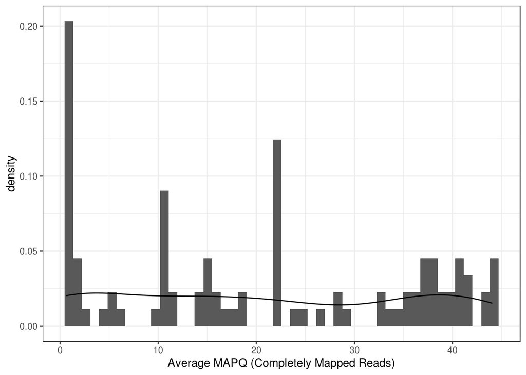

```r
library(ggplot2)
ggplot(allele_mapping_data, aes(`Average MAPQ (Completely Mapped Reads)`)) +
  geom_histogram(bins=50, aes(y = stat(density)))+geom_density()+theme_bw()
```

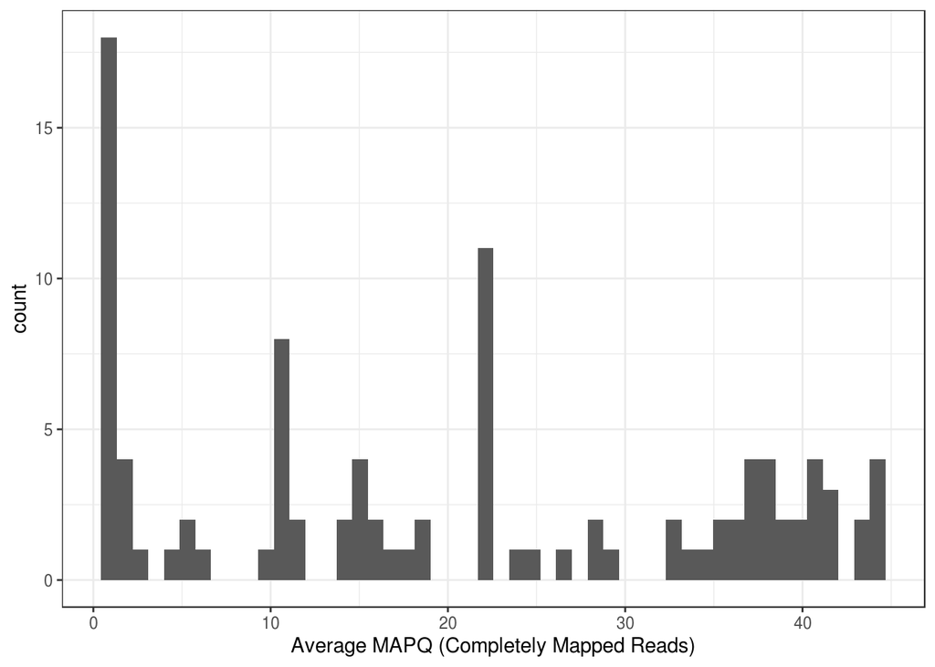

```r
ggplot(allele_mapping_data, aes(`Average MAPQ (Completely Mapped Reads)`)) +
  geom_histogram(bins=50)+theme_bw()
```

### Apply Average MAPQ filter:

```r
allele_mapping_data<-allele_mapping_data%>%filter(`Average MAPQ (Completely Mapped Reads)`>10)
```

### RPKM sum per AMR gene family

```r
library(knitr)
n_distinct(allele_mapping_data$`AMR Gene Family`)
```

```
## [1] 33
```

```r
AMR_family_RGI<-allele_mapping_data%>%
  group_by(`AMR Gene Family`)%>%
  summarise('number of AMR genes per family (RGI)'=n(),
            sum_RPKM_RGI=sum(RPKM),
            avg_MAPQ=mean(`Average MAPQ (Completely Mapped Reads)`),
            q1_MAPQ=quantile(`Average MAPQ (Completely Mapped Reads)`, 0.25),
            p3_MAPQ=quantile(`Average MAPQ (Completely Mapped Reads)`,0.75),)%>%arrange(desc(sum_RPKM_RGI))
kable(head(AMR_family_RGI))
```

| AMR Gene Family | number of AMR genes per family (RGI) | sum_RPKM_RGI | avg_MAPQ | q1_MAPQ | p3_MAPQ |
| --- | --- | --- | --- | --- | --- |
| tetracycline-resistant ribosomal protection protein | 7 | 323.27947 | 36.37286 | 36.28 | 40.87 |
| Erm 23S ribosomal RNA methyltransferase | 5 | 163.85883 | 37.97400 | 36.67 | 38.00 |
| ABC-F ATP-binding cassette ribosomal protection protein | 5 | 55.17338 | 25.74400 | 18.33 | 35.75 |
| tetracycline inactivation enzyme | 2 | 49.96357 | 25.45000 | 23.84 | 27.06 |
| CblA beta-lactamase | 1 | 39.70540 | 38.02000 | 38.02 | 38.02 |
| CfxA beta-lactamase | 1 | 28.40391 | 26.39000 | 26.39 | 26.39 |

```r
str(AMR_family_RGI$`sum RPKM (RGI)`)
```

[output not shown]

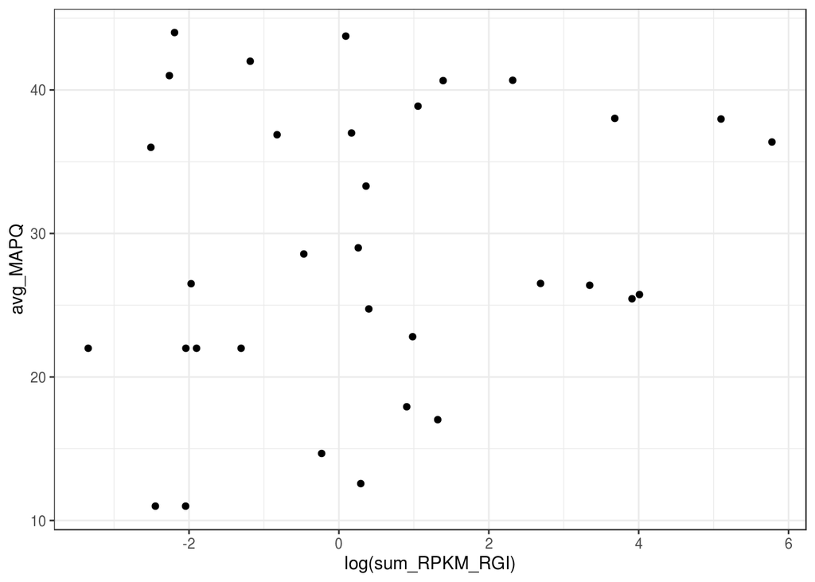

```r
ggplot(AMR_family_RGI, aes(log(sum_RPKM_RGI), avg_MAPQ))+geom_point()+theme_bw()
```

# ARIBA

```r
report <- read_delim("ARIBA/report.tsv",
    "\t", escape_double = FALSE, trim_ws = TRUE)
```

report1: only coding sequences report2: all sequences Remove contig and variant data

```r
report1<-report%>% filter(gene==1)%>%select(c(1:8,31))%>%unique()
report2<-report%>%select(c(1:8,31))%>%unique()
dim(report1)
```

```
## [1] 24  9
```

```r
dim(report2)
```

```
## [1] 35  9
```

I will use the total nº of reads instead mapped reads

```r
AribaMapReds<-5803 ##obtained from minimap.properPairs
totalNumReads<- 17072992
report<-report2%>%mutate(RPKM=reads /(ref_len/1000 * totalNumReads/1000000))
```

### Obtain AMR gene family

Import CARD data aro index:

```r
library(readr)
aro_index <- read_delim("aro_index.tsv",
    "\t", escape_double = FALSE, trim_ws = TRUE)
```

Trasform ARIBA notation to merge with CARD DB

```r
library(stringr)
library(reshape2)
y<-colsplit(report$ref_name, "\\.", c("ARO Term", "ARO Acession","NCBI","init_final","Model Sequence ID","X"))
y$NCBI<-ifelse(str_detect(y$init_final, "_"),y$NCBI ,paste(y$NCBI,".",y$init_final) )
y$init_final<-ifelse(str_detect(y$init_final, "_"), y$init_final, y$`Model Sequence ID`)
y$`Model Sequence ID`<-ifelse(str_detect(y$`Model Sequence ID`, "_"), y$X, y$`Model Sequence ID`)
y<-select(y, -X)
report<-cbind(report,y)

report<-merge(report, select(aro_index,`Model Sequence ID`, `AMR Gene Family`,`Drug Class`, `Resistance Mechanism` ) , by="Model Sequence ID")
```

Mapping quality?

### RPKM sum per AMR gene family

```r
library(knitr)
library(dplyr)
AMR_family_ARIBA<-report%>%
  group_by(`AMR Gene Family`)%>%
  summarise('number of AMR genes per family(ARIBA)'=n(),
            'sum RPKM (ARIBA)'=sum(RPKM))%>%arrange(desc('sum RPKM (ARIBA)'))

kable(head(AMR_family_ARIBA))
```

| AMR Gene Family | number of AMR genes per family(ARIBA) | sum RPKM (ARIBA) |
| --- | --- | --- |
| 16s rRNA with mutation conferring resistance to aminoglycoside antibiotics | 3 | 62.51317 |
| 23S rRNA with mutation conferring resistance to linezolid antibiotics | 1 | 23.14056 |
| 23S rRNA with mutation conferring resistance to macrolide antibiotics | 4 | 47.71525 |
| 23S rRNA with mutation conferring resistance to macrolide antibiotics;23S rRNA with mutation conferring resistance to streptogramins antibiotics | 1 | 20.93587 |
| 23S rRNA with mutation conferring resistance to oxazolidinone antibiotics | 1 | 25.21179 |
| 23S rRNA with mutation conferring resistance to pleuromutilin antibiotics | 1 | 13.20047 |

# GROOT

Get groot report (uniqseq)

```r
library(readr)
groot_report <- read_delim("Groot/filtered_RTC_149-uniqseq-0report",
    "\t", escape_double = FALSE, col_names = FALSE,
    trim_ws = TRUE)
names(groot_report)<-c("AMR.gene", "read.count", "gene.length", "coverage.cigar")
head(groot_report)
```

```
## # A tibble: 6 x 4
##   AMR.gene                                 read.count gene.length coverage.cigar
##   <chr>                                         <dbl>       <dbl> <chr>
## 1 TEM-54.3000923.AF104442.193-1054.1959             1         861 71D108M682D
## 2 lnuC.3002837.AY928180.0-495.110                   2         495 94D132M269D
## 3 TEM-183.3001045.HQ529916.110-971.1647             2         861 340D194M327D
## 4 APH(2'')-IVa.3002637.AF016483.0-906.729           1         906 661D152M93D
## 5 TEM-168.3001034.FJ919776.208-1069.999             1         861 300D152M409D
## 6 Pasteurella_multocida_16S.3003493.NC_00…          1        1551 663D152M736D
```

Report: This will report gene, read count, gene length, coverage cigar" Trasform GROOT notation and merge with CARD DB

```r
library(stringr)
library(reshape2)
library(dplyr)
y<-colsplit(groot_report$AMR.gene, "\\.", c("ARO Term", "ARO Acession","NCBI","init_final","Model Sequence ID","X"))

y$NCBI<-ifelse(str_detect(y$init_final, "-"),y$NCBI ,paste(y$NCBI,".",y$init_final) )
y$init_final<-ifelse(str_detect(y$init_final, "-"), y$init_final, y$`Model Sequence ID`)
y$`Model Sequence ID`<-ifelse(str_detect(y$`Model Sequence ID`, "-"), y$X, y$`Model Sequence ID`)
y<-select(y, -X)
groot_report<-cbind(groot_report,y)
groot_report<-merge(groot_report, select(aro_index,`Model Sequence ID`, `AMR Gene Family`,`Drug Class`, `Resistance Mechanism` ) , by="Model Sequence ID")
```

Calculate RPKM:

```r
totalNumReads<- 17072992
groot_report<-groot_report%>%mutate(RPKM=read.count /(gene.length/1000 * totalNumReads/1000000))
```

```r
library(knitr)
n_distinct(groot_report$`AMR Gene Family`)
```

```
## [1] 21
```

```r
AMR_family_Groot<-groot_report%>%
  group_by(`AMR Gene Family`)%>%
  summarise('number of AMR genes per family (groot)'=n(),
            sum_RPKM_groot=sum(RPKM))%>%arrange(desc(sum_RPKM_groot))
kable(head(AMR_family_Groot))
```

| AMR Gene Family | number of AMR genes per family (groot) | sum_RPKM_groot |
| --- | --- | --- |
| CfxA beta-lactamase | 6 | 108.996902 |
| tetracycline-resistant ribosomal protection protein | 7 | 41.146459 |
| Erm 23S ribosomal RNA methyltransferase | 4 | 32.751179 |
| tetracycline inactivation enzyme | 2 | 32.021390 |
| CblA beta-lactamase | 1 | 12.555847 |
| ANT(6) | 1 | 5.491129 |

# ARIBA vs RGI vs GROOT

```r
length(AMR_family_ARIBA$`AMR Gene Family`)
```

```
## [1] 21
```

```r
length(AMR_family_RGI$`AMR Gene Family`)
```

```
## [1] 33
```

```r
length(AMR_family_Groot$`AMR Gene Family`)
```

```
## [1] 21
```

```r
AMR_family<-merge(AMR_family_ARIBA, AMR_family_RGI[ ,1:3], by="AMR Gene Family", all=TRUE)
AMR_family<-merge(AMR_family, AMR_family_Groot, by="AMR Gene Family", all=TRUE)

kable(arrange(AMR_family,`number of AMR genes per family(ARIBA)`))
```

| AMR Gene Family | number of AMR genes per family(ARIBA) | sum RPKM (ARIBA) | number of AMR genes per family (RGI) | sum_RPKM_RGI | number of AMR genes per family (groot) | sum_RPKM_groot |
| --- | --- | --- | --- | --- | --- | --- |
| 23S rRNA with mutation conferring resistance to linezolid antibiotics | 1 | 23.1405606 | NA | NA | NA | NA |
| 23S rRNA with mutation conferring resistance to macrolide antibiotics;23S rRNA with mutation conferring resistance to streptogramins antibiotics | 1 | 20.9358744 | NA | NA | 1 | 0.0806777 |
| 23S rRNA with mutation conferring resistance to oxazolidinone antibiotics | 1 | 25.2117948 | NA | NA | NA | NA |
| 23S rRNA with mutation conferring resistance to pleuromutilin antibiotics | 1 | 13.2004740 | NA | NA | NA | NA |
| ABC-F ATP-binding cassette ribosomal protection protein | 1 | 31.1614803 | 5 | 55.1733791 | 2 | 0.4554283 |
| ACI beta-lactamase | 1 | 1.2330956 | 1 | 1.0960850 | 1 | 0.4795372 |
| ANT(6) | 1 | 14.1006767 | 3 | 14.7435642 | 1 | 5.4911289 |
| APH(3’) | 1 | 2.9470210 | 1 | 2.8733454 | 1 | 1.2524839 |
| CblA beta-lactamase | 1 | 39.0480278 | 1 | 39.7054020 | 1 | 12.5558473 |
| lincosamide nucleotidyltransferase (LNU) | 1 | 2.6032019 | 2 | 4.0174618 | 2 | 0.3535650 |
| rifamycin-resistant beta-subunit of RNA polymerase (rpoB) | 1 | 0.1973784 | 2 | 3.7379985 | NA | NA |
| sulfonamide resistant sul | 1 | 1.4355893 | 1 | 1.4355893 | 1 | 0.5024562 |
| TEM beta-lactamase | 1 | 4.3537871 | 1 | 1.4905232 | 22 | 2.1088656 |
| tetracycline inactivation enzyme | 1 | 68.5599049 | 2 | 49.9635744 | 2 | 32.0213904 |
| trimethoprim resistant dihydrofolate reductase dfr | 1 | 1.4199283 | 1 | 1.1832736 | 1 | 0.5916368 |
| CfxA beta-lactamase | 2 | 207.8804150 | 1 | 28.4039118 | 6 | 108.9969023 |
| major facilitator superfamily (MFS) antibiotic efflux pump | 2 | 9.9702373 | 3 | 10.1672388 | 2 | 4.1648461 |
| 16s rRNA with mutation conferring resistance to aminoglycoside antibiotics | 3 | 62.5131685 | NA | NA | 1 | 0.0377641 |
| Erm 23S ribosomal RNA methyltransferase | 3 | 162.7884433 | 5 | 163.8588316 | 4 | 32.7511795 |
| 23S rRNA with mutation conferring resistance to macrolide antibiotics | 4 | 47.7152528 | NA | NA | 4 | 0.7612817 |
| tetracycline-resistant ribosomal protection protein | 6 | 242.5141847 | 7 | 323.2794719 | 7 | 41.1464591 |
| 23S rRNA with mutation conferring resistance to lincosamide antibiotics | NA | NA | NA | NA | 1 | 0.0605083 |
| ANT(9) | NA | NA | 1 | 0.1496093 | NA | NA |
| antibiotic-resistant isoleucyl-tRNA synthetase (ileS) | NA | NA | 1 | 0.0352419 | NA | NA |
| APH(2’’) | NA | NA | 1 | 0.1292981 | 1 | 0.0646491 |
| APH(2’‘); AAC(6’) | NA | NA | 1 | 0.0813501 | NA | NA |
| ATP-binding cassette (ABC) antibiotic efflux pump | NA | NA | 2 | 0.6260984 | NA | NA |
| cepA beta-lactamase | NA | NA | 1 | 0.1297277 | NA | NA |
| chloramphenicol acetyltransferase (CAT) | NA | NA | 3 | 2.6741926 | NA | NA |
| General Bacterial Porin with reduced permeability to beta-lactams | NA | NA | 1 | 0.1041281 | NA | NA |
| glycopeptide resistance gene cluster; van ligase | NA | NA | 1 | 0.1115658 | NA | NA |
| glycopeptide resistance gene cluster; vanR | NA | NA | 2 | 1.3385745 | NA | NA |
| glycopeptide resistance gene cluster;vanT | NA | NA | NA | NA | 1 | 0.0547658 |
| glycopeptide resistance gene cluster; vanT | NA | NA | 1 | 0.4381265 | NA | NA |
| glycopeptide resistance gene cluster; vanXY | NA | NA | 1 | 0.3062590 | NA | NA |
| Llm 23S ribosomal RNA methyltransferase | NA | NA | 1 | 0.2711669 | NA | NA |
| macrolide phosphotransferase (MPH) | NA | NA | 1 | 0.7941972 | NA | NA |
| multidrug and toxic compound extrusion (MATE) transporter | NA | NA | 1 | 0.0863894 | NA | NA |
| pmr phosphoethanolamine transferase | NA | NA | 2 | 0.1391651 | NA | NA |
| resistance-nodulation-cell division (RND) antibiotic efflux pump | NA | NA | 14 | 2.4712763 | NA | NA |
| streptothricin acetyltransferase (SAT) | NA | NA | 1 | 1.2944098 | 1 | 0.1078675 |

```r
write_tsv(AMR_family, "AMR_family_ARIBAall_groot_uniqseq.tsv")
```